# R の「あるある」エラー

Masahiko Asano

2022-10-20

- **このセクションで使っている `R packages`**

```r
library(DT)
library(gapminder)
library(gghighlight)
library(ggrepel)
library(stargazer)
library(tidyverse)
```

# 1. R を使う時の「あるある」エラー

- R を使って計量分析するために必要なのはデータの読み取り
- しかし、いくつかの典型的なエラーが起こる
- ここでは皆さんが直面するであろう「あるある」エラーの内容とその原因と対処法を提供する

## 1.1 パッケージがインストールできない

- 原因はいくつか考えられる

#### 原因 1: タイプミス

- 例えば、次のような単純な「打ち間違い」：

|  |  | 間違い箇所 |
| --- | --- | --- |
| **正しいコード** | **`install.packages("tidyverse")`** |  |
| 誤ったコード | **`install.package("tidyverse")`** | `package` → `packages` |
| 誤ったコード | **`install.packages(tidyverse)`** | `tidyverse` → `"tidyverse"` |
| 誤ったコード | **`install.packages ("tidyverse")`** | `(` 前の半角スペース |
| 誤ったコード | **`install.packages("tidiverse")`** | `tidiverse` → `tidyverse` |

##### 対処法：

- 正確に入力する

#### 原因 2 : `Console` に入力していないため

- `Console` ではなく `Rmd` ファイルのチャンクの中に入力してしまうことがよくある

##### 対処法：

- 正確に入力する
- `install.packages("パッケージ名")` は`Console` に入力する

#### 原因 3: 「パッケージが `CRAN` に置かれていないため」

##### 対処法：

- 正確に入力する
- 次のコマンドを `Console` に打ち込んで `Github` からダウンロードする

```r
install.packages("remotes")
remotes::install_github("uribo/jpndistrict")
```

#### 原因 4: 「必要なパッケージがダウンロードできていないため」

- 例えば、`rnaturalearth` というパッケージをインストールする際には、`rnaturalearth` を作動させるために必要な他のパッケージも同時にインストールしてみる

##### 対処法：

- 正確に入力する
- インストールするコマンドに `dependencies = TRUE` を加える

```r
install.packages("rnaturalearth", dependencies = TRUE)
```

## 1.2 `csv`ファイルが読み取れない

- 複数の原因が考えられる

#### 原因 1: `csv` ファイル自体が「壊れている」場合

- 読み取ろうとしている `csv` ファイルがきちんと開けるかどうか確認してみる

##### 対処法：

- 正確に入力する
- `csv` ファイルの破損を修理する

#### 原因 2: `csv` ファイルのエンコードが `UTF-8` でない

##### 対処法：

- 正確に入力する
- `csv` ファイルのエンコードを `UTF-8` に指定して保存し直す

#### 原因 3: `csv` ファイルが「Rプロジェクト」内に保存されていない

##### 対処法：

- 正確に入力する
- `csv` ファイルを「Rプロジェクト」内に保存する

# 2. パッケージのインストールとロード

## 2.1 パッケージを使うための 2 ステップ

・**Step 1**: `install.packages("パッケージ名")`  
・**Step 2**: `library(パッケージ名)` もしくは `library("パッケージ名")`

- 例えば、`DT` というパッケージを使うためには、次の 2 ステップが必要

[output not shown]

## 2.2 パッケージをロードする 2 つの方法

- 例えば、`df1` という名前のデータフレームを使って `DT` というパッケージの `datatable()` という関数を使う場合
- 次の 2 通りの方法が可能

★ 次の 2 行をチャンクに打ち込む

```r
library(DT)
datatable(df1)
```

★ 次の 1 行をチャンクに打ち込む

```r
DT::datatable(df1)
```

- この補助教材ではどちらの方法も使っている

パッケージ間のコンフリクトの解説  
・例えば、`tidyverse` というパッケージをインストールしロードすると次のように表示される

```r
library(tidyverse)
```

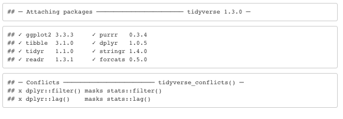

**メッセージの意味：**

・`tidyverse` パッケージをロードすると、同時に 8 つのパッケージがロードされる ・`tidyverse` パッケージは `filter()` と `lag()` という 2 つの関数とコンフリクト（＝エラー）を起こす  
→ `filter()`関数を使う際、エラーを避けるため次のようにコマンドを入力する必要がある  
`filter()` → **`dplyr::filter()`**

# 3. R プロジェクトを作る

- `RStudio` を使ってデータ分析する上で重要なのは**「R プロジェクトをつくること」**
- 「R プロジェクトをつくること」= 「R プロジェクト**フォルダ**を作ること」
- **「フォルダ」**とは**「ディレクトリ」**のこと
- 正しい**「作業ディレクトリ (`working directory`)」**の中で作業しないとエラーになる
- この「作業ディレクトリ」= 「フォルダ」の中には分析に必要な複数の「ファイル」が入っている
- RStudio は分析に必要な「ファイル」を、指定された「Rプロジェクトフォルダ」（= 作業中のディレクトリ）から引き出す  
  → R プロジェクトをつくらないと「エラーを起こす確率が高くなる」
- 自分がどの「フォルダ」の中で作業しているか（= どの「ディレクトリ」の中で作業しているか）を確かめる方法
- 次のコマンドで確かめることができる

```r
getwd()  # get working directry の略
```

```
[1] "/Users/asanomasahiko/Dropbox/statistics/class_materials"
```

- `working directory` にはデータ分析に必要なファイル（データや `script`など） を保存するので、常に確認しておくこと
- エラーが出た特に `getwd()` で自分が「どこで作業しているのか」をチェックする
- もし、自分が作成した R プロジェクトフォルダの中にいない場合は、R プロジェクトフォルダの中にある`「.Rproj」`で終わるアイコンをダブルクリックする
- `RStudio` では、分析テーマごとに新たなプロジェクトを作成するのがよい  
  → いちいち `getwd()` でチェックしなくても、確実にデータを読み込んでくれる  
  → エラーが少なくなる
- **File** から **New Project** を選び、指示に従って作成すると、`RProject` は `project folder` を自動的に `working directory` だと認識する
- `RStudio` 右画面下部画面にある **File** をクリックすると、作成した `RProject` フォルダー内にあるファイルが表示される

# 4. データの準備 (`hr96-21.csv`)

- データを可視化するために必要なのは「適切ななデータ」を準備すること
- 「適切なデータ」とはデータを可視化する上で、エラーが出ず、問題なく必要なグラフを作成できるようなデータのこと
- ここでは、データを可視化したり、計量分析したりするために必要なデータを準備する

## 4.1 データのダウンロード方法

- Web 上に公開されているデータをパソコンにダウンロードする方法は 2 つある

##### (1) 予めダウンロード先を指定する方法

- `RProject` フォルダ内に **data** という名称のフォルダを作成する
- 下のコマンドを実行すると、`csv` ファイルがパソコンにダウンロードされ、**data** 内に自動的に保存される

```r
download.file(url = "[hr96-21.csv](https://asanoucla.github.io/hr96-21.csv)",
              destfile = "data/hr96-21.csv")
```

注意：一度ダウンロードを完了すれば、このコマンドを実行する必要はありません

##### (2) ダウンロード先を指定しない方法

- hr96-21.csv をクリックしてデータをパソコンにダウンロード
- `RProject` フォルダ内に **data** という名称のフォルダを作成する
- ダウンロードした `hr96-21.csv` を手動で`RProject` フォルダ内にある **data** フォルダに入れる

## 4.2 選挙データの読み取り方法

- 次の**いずれかの方法で** `hr96-21.csv` を読み取る

##### 読み取り方法 1

- `na = "."`というコマンドは「欠損値をドットで置き換える」という意味
- このように指定すると、変数内の「`空欄`」は「`.`」で置き換わる
- 欠損値を空欄のまま残すと、本来「数値 (`numeric`)」型のデータが「」文字型 (`character`)」として認識されるなど、エラーの原因になるため、読み取る時点で事前に対処する

```r
hr <- read_csv("data/hr96-21.csv",
               na = ".")
```

##### 読み取り方法 2

- 読み取った値の日本語が文字化けする場合
- `locale()`関数を使って日本語エンコーディング (`cp932`) を指定する

```r
hr <- read_csv("data/hr96-21.csv",
               na = ".",
               locale = locale(encoding = "cp932"))
```

##### 読み取り方法 3

- `readrパッケージ`を使わないで読み取る

```r
hr <- read.csv("data/hr96-21.csv",
               na = ".")
```

## 4.3 読み取った選挙データを確認

- `hr96_17.csv` は1996年に衆院選挙に小選挙区が導入されて以来実施された 9 回の衆議院選挙（1996, 2000, 2003, 2005, 2009, 2012, 2014, 2017, 2021）の結果のデータ
- `hr` に含まれる変数名を表示させる

```r
names(hr)
```

```
 [1] "year"          "pref"          "ku"            "kun"
 [5] "wl"            "rank"          "nocand"        "seito"
 [9] "j_name"        "gender"        "name"          "previous"
[13] "age"           "exp"           "status"        "vote"
[17] "voteshare"     "eligible"      "turnout"       "seshu_dummy"
[21] "jiban_seshu"   "nojiban_seshu"
```

- `df1` には 22 個の変数が入っている

[output not shown]

- データの型をチェック

```r
str(hr)
```

```
spec_tbl_df [9,660 × 22] (S3: spec_tbl_df/tbl_df/tbl/data.frame)
 $ year         : num [1:9660] 1996 1996 1996 1996 1996 ...
 $ pref         : chr [1:9660] "愛知" "愛知" "愛知" "愛知" ...
 $ ku           : chr [1:9660] "aichi" "aichi" "aichi" "aichi" ...
 $ kun          : num [1:9660] 1 1 1 1 1 1 1 2 2 2 ...
 $ wl           : num [1:9660] 1 0 0 0 0 0 0 1 0 2 ...
 $ rank         : num [1:9660] 1 2 3 4 5 6 7 1 2 3 ...
 $ nocand       : num [1:9660] 7 7 7 7 7 7 7 8 8 8 ...
 $ seito        : chr [1:9660] "新進" "自民" "民主" "共産" ...
 $ j_name       : chr [1:9660] "河村たかし" "今枝敬雄" "佐藤泰介" "岩中美保子" ...
 $ gender       : chr [1:9660] "male" "male" "male" "female" ...
 $ name         : chr [1:9660] "KAWAMURA, TAKASHI" "IMAEDA, NORIO" "SATO, TAISUKE" "IWANAKA, MIHOKO" ...
 $ previous     : num [1:9660] 2 2 2 0 0 0 0 2 0 0 ...
 $ age          : num [1:9660] 47 72 53 43 51 51 45 51 71 30 ...
 $ exp          : num [1:9660] 9828097 9311555 9231284 2177203 NA ...
 $ status       : num [1:9660] 1 2 1 0 0 0 0 1 2 0 ...
 $ vote         : num [1:9660] 66876 42969 33503 22209 616 ...
 $ voteshare    : num [1:9660] 40 25.7 20.1 13.3 0.4 0.3 0.2 32.9 26.4 25.7 ...
 $ eligible     : num [1:9660] 346774 346774 346774 346774 346774 ...
 $ turnout      : num [1:9660] 49.2 49.2 49.2 49.2 49.2 49.2 49.2 51.8 51.8 51.8 ...
 $ seshu_dummy  : num [1:9660] 0 0 0 0 0 0 0 0 1 0 ...
 $ jiban_seshu  : chr [1:9660] NA NA NA NA ...
 $ nojiban_seshu: chr [1:9660] NA NA NA NA ...
 - attr(*, "spec")=
  .. cols(
  ..   year = col_double(),
  ..   pref = col_character(),
  ..   ku = col_character(),
  ..   kun = col_double(),
  ..   wl = col_double(),
  ..   rank = col_double(),
  ..   nocand = col_double(),
  ..   seito = col_character(),
  ..   j_name = col_character(),
  ..   gender = col_character(),
  ..   name = col_character(),
  ..   previous = col_double(),
  ..   age = col_double(),
  ..   exp = col_double(),
  ..   status = col_double(),
  ..   vote = col_double(),
  ..   voteshare = col_double(),
  ..   eligible = col_double(),
  ..   turnout = col_double(),
  ..   seshu_dummy = col_double(),
  ..   jiban_seshu = col_character(),
  ..   nojiban_seshu = col_character()
  .. )
 - attr(*, "problems")=<externalptr>
```

- 数値は `numeric` 文字は `character` として認識されていることがわかる

## 4.4 総選挙データの読込と変数の修正・作成

- 新たな変数の作成と修正

##### **wlsmd の作成**

- `wl = 1` は小選挙区当選者、`wl = 2` は復活当選者、`wl = 0` は落選者

```r
table(hr$wl)
```

```
   0    1    2
6001 2674  985
```

- `wlsmd = 1` が小選挙区当選者, `wlsmd = 0` が小選挙区の落選者と変更し、データフレーム名を `df1` に変更
- `if_else()` 関数を使う

```r
df1 <- hr %>%
  mutate(wlsmd = ifelse(wl == 1, 1, 0))
```

- 変更を確認

```r
table(df1$wlsmd)
```

```
   0    1
6986 2674
```

##### **exppv （有権者一人あたり選挙費用）の作成**

- `exp` と `eligible` を使って、有権者一人あたりに使う選挙費用 (`exppv`) を作る

```r
df1 <- mutate(df1, exppv = exp / eligible) # eligible は小選挙区ごとの有権者数
```

```r
summary(df1$exppv)
```

```
    Min.  1st Qu.   Median     Mean  3rd Qu.     Max.     NA's
  0.0013   8.1762  18.7646  23.0907  33.3863 120.8519     2831
```

- exppv を作成する際にエラーが出た時の対処法
- `df1 <- mutate(df1, exppv = exp / eligible)` を**実行する前に**次の処理をする
- チャンクの中に打ち込んだ `df1 <- mutate(df1, exppv = exp / eligible)` は削除し、下の一連の作業が終わった後で打ち直すこと
- チャンクの中に打ち込んだ `df1 <- mutate(df1, exppv = exp / eligible)` を残したまま下の一連の作業を実行すると、そのチャンクのところでエラーになってしまうから

[output not shown]

#### 「数値型」のはずなのに「文字型」と認識される場合の対処法

- R では時々 `exp` や `eligible` のデータの「型」が「数値型 (`numeric`)」ではなく「文字型」(`charactor`) として読み取られることがある
- その場合はまず、次の作業を行う：  
  **(1) 変数の値に数値以外が入っていないか確かめる**  
  → 入っていれば数値に修正する  
  **(2) 変数の値が「全角」になっていないか確かめる**  
  → 全角の数字が入っていたら「半角」に修正する
- 以上の作業を行っても「数値型 (`numeric`)」ではなく「文字型」(`charactor`) として読み取られる場合  
  → `as.numeric()`関数を使って、データの型を「数値型 (`numeric`)」に変換する必要がある

##### **inc （現職ダミー）の作成**

- `status = 0` は新人、`status = 1` は現職、 `status = 2` は元職

```r
table(df1$status)
```

```
   0    1    2
5517 3510  633
```

- これを次のように変更：
- `status = 0` がその他、`status = 1` が現職

```r
df1 <- hr %>%
  mutate(inc = if_else(status == 1, 1, 0))
```

```r
table(df1$inc)
```

```
   0    1
6150 3510
```

- 修正後のデータフレーム (`df1`) を表示

```r
names(df1)
```

```
 [1] "year"          "pref"          "ku"            "kun"
 [5] "wl"            "rank"          "nocand"        "seito"
 [9] "j_name"        "gender"        "name"          "previous"
[13] "age"           "exp"           "status"        "vote"
[17] "voteshare"     "eligible"      "turnout"       "seshu_dummy"
[21] "jiban_seshu"   "nojiban_seshu" "inc"
```

##### **ldp （自民党ダミー）の作成**

```r
table(df1$seito)
```

```
                                         Ｎ党           アイヌ民族党
                     1                     27                      1
さわやか神戸・市民の会     ニューディールの会                 みんな
                     2                      1                     79
                  れい       世界経済共同体党                   保守
                    12                      2                     16
                保守新                   公明                   共産
                    11                     79                   2228
                  国民                 国民党               国民新党
                    21                     11                     21
              安楽死党       市民新党にいがた                   希望
                     1                      1                    199
                  幸福               当たり前                   改革
                   312                      1                      1
            改革クラブ         政事公団太平会           政治団体代表
                     4                      1                      2
        文化フォーラム           新党さきがけ               新党大地
                    10                     13                      8
              新党尊命               新党日本                 新社会
                     1                      9                     38
                  新進               日本新進               日本未来
                   235                      1                    111
          日本維新の会                   次世                   民主
                   198                     39                   1654
          民主改革連合         沖縄社会大衆党                   無所
                     2                      1                    641
            無所属の会                   生活                   社民
                     9                     13                    316
                  立憲                   維新                 緑の党
                   277                    171                      1
                  緒派                   自民                   自由
                    44                   2542                     61
              自由連合                   諸派               青年自由
                   212                     18                      1
```

- `seito` を使って自民党ダミー (`ldp`) を作る
- `ldp = 1` は自民党候補者、`ldp = 0` は非自民党候補者

```r
df1 <- hr %>%
  mutate(ldp = if_else(seito == "自民", 1, 0))
```

```r
table(df1$ldp)
```

```
   0    1
7118 2542
```

- 修正後のデータフレーム (`df1`) を表示

```r
names(df1)
```

```
 [1] "year"          "pref"          "ku"            "kun"
 [5] "wl"            "rank"          "nocand"        "seito"
 [9] "j_name"        "gender"        "name"          "previous"
[13] "age"           "exp"           "status"        "vote"
[17] "voteshare"     "eligible"      "turnout"       "seshu_dummy"
[21] "jiban_seshu"   "nojiban_seshu" "ldp"
```

- `df1` には 23 個の変数が入っている

[output not shown]

## 4.5 総選挙データの記述統計

- 総選挙データ (`df1`) の変数の記述統計を表示させる

```r
library(stargazer)
```

- チャンクオプションで `{r, results = "asis"}` と指定する

```r
stargazer(as.data.frame(df1),
          type ="html",
          digits = 2)
```

| Statistic | N | Mean | St. Dev. | Min | Max |
| --- | --- | --- | --- | --- | --- |
| year | 9,660 | 2,007.88 | 7.68 | 1,996 | 2,021 |
| kun | 9,660 | 5.75 | 5.07 | 1 | 25 |
| wl | 9,660 | 0.48 | 0.67 | 0 | 2 |
| rank | 9,660 | 2.65 | 20.39 | 1 | 2,003 |
| nocand | 9,660 | 3.89 | 1.09 | 2 | 9 |
| previous | 9,660 | 1.48 | 2.46 | 0 | 19 |
| age | 9,656 | 51.22 | 11.13 | 25 | 94 |
| exp | 6,829 | 7,551,393.00 | 5,482,684.00 | 535 | 27,462,362 |
| status | 9,660 | 0.49 | 0.62 | 0 | 2 |
| vote | 9,660 | 55,987.87 | 40,626.34 | 177 | 210,515 |
| voteshare | 9,660 | 27.67 | 19.34 | 0.10 | 95.30 |
| eligible | 8,785 | 330,268.30 | 80,058.87 | 115,013 | 495,212 |
| turnout | 7,849 | 62.09 | 6.53 | 44.71 | 83.80 |
| seshu_dummy | 8,875 | 0.12 | 0.33 | 0 | 1 |
| ldp | 9,660 | 0.26 | 0.44 | 0 | 1 |

- `df1` には 23 個の変数が入っている
- しかし、ここには 15 個の変数の記述統計しか表示されていない

**その理由：**

- 記述統計で表示されるのは変数の「型」 `class` が「数値型」( `numeric`, `integer`, `double` )の場合だけだから
- 文字型データ (`chr`) や ファクター (`factor`) の場合は記述統計が表示されない

**R で可視化する際、変数の class の違いはとても重要**

- 「データの型」に関する詳細は [「私たちの R: 9.1 データ型」](https://www.jaysong.net/RBook/datatype.html) を参考
- `str()`関数で、`df1` に含まれる変数の `class` を確認してみる

```r
str(df1)
```

```
tibble [9,660 × 23] (S3: tbl_df/tbl/data.frame)
 $ year         : num [1:9660] 1996 1996 1996 1996 1996 ...
 $ pref         : chr [1:9660] "愛知" "愛知" "愛知" "愛知" ...
 $ ku           : chr [1:9660] "aichi" "aichi" "aichi" "aichi" ...
 $ kun          : num [1:9660] 1 1 1 1 1 1 1 2 2 2 ...
 $ wl           : num [1:9660] 1 0 0 0 0 0 0 1 0 2 ...
 $ rank         : num [1:9660] 1 2 3 4 5 6 7 1 2 3 ...
 $ nocand       : num [1:9660] 7 7 7 7 7 7 7 8 8 8 ...
 $ seito        : chr [1:9660] "新進" "自民" "民主" "共産" ...
 $ j_name       : chr [1:9660] "河村たかし" "今枝敬雄" "佐藤泰介" "岩中美保子" ...
 $ gender       : chr [1:9660] "male" "male" "male" "female" ...
 $ name         : chr [1:9660] "KAWAMURA, TAKASHI" "IMAEDA, NORIO" "SATO, TAISUKE" "IWANAKA, MIHOKO" ...
 $ previous     : num [1:9660] 2 2 2 0 0 0 0 2 0 0 ...
 $ age          : num [1:9660] 47 72 53 43 51 51 45 51 71 30 ...
 $ exp          : num [1:9660] 9828097 9311555 9231284 2177203 NA ...
 $ status       : num [1:9660] 1 2 1 0 0 0 0 1 2 0 ...
 $ vote         : num [1:9660] 66876 42969 33503 22209 616 ...
 $ voteshare    : num [1:9660] 40 25.7 20.1 13.3 0.4 0.3 0.2 32.9 26.4 25.7 ...
 $ eligible     : num [1:9660] 346774 346774 346774 346774 346774 ...
 $ turnout      : num [1:9660] 49.2 49.2 49.2 49.2 49.2 49.2 49.2 51.8 51.8 51.8 ...
 $ seshu_dummy  : num [1:9660] 0 0 0 0 0 0 0 0 1 0 ...
 $ jiban_seshu  : chr [1:9660] NA NA NA NA ...
 $ nojiban_seshu: chr [1:9660] NA NA NA NA ...
 $ ldp          : num [1:9660] 0 1 0 0 0 0 0 0 1 0 ...
```

- 数値は数値型 (`numeric`)、文字は文字型 (`character`) になっている
- **文字型 (`character`) の値は「`""`」で囲まれいていることに注意**
- 欠損値は `NA` で表示されている

##### これで、計量分析に必要な衆院選のデータが揃った

**参考文献**

[Tidy Animated Verbs](https://github.com/gadenbuie/tidyexplain?fbclid=IwAR3Zt0pQZa0IEvP-1gstatQ42VM5yJZvw2vUaFEqt_m2smUgtZpTqvuurLJ6z0)

[宋財泫 (Jaehyun Song)・矢内勇生 (statuki statanai)「私たちのR: ベストプラクティスの探究」](https://www.jaysong.net/RBook/)

[宋財泫「ミクロ政治データ分析実習（2022年度）」](https://www.jaysong.net/micro-book/)

[土井翔平（北海道大学公共政策大学院）「Rで計量政治学入門」](https://shohei-doi.github.io/quant_polisci/data-import.html)

[矢内勇生（高知工科大学）授業一覧](http://yukiyanai.github.io/teaching/)

浅野正彦, 矢内勇生.『Rによる計量政治学』オーム社、2018年

浅野正彦, 中村公亮.『初めてのRStudio』オーム社、2018年

Kieran Healy, DATA VISUALIZATION, Princeton, 2019

Kosuke Imai, Quantitative Social Science: An Introduction, Princeton University Press, 2017